# AE 08

For Loops and the Bootstrap

Scott Burstein

Due: Sep 16, 11:59 PM

## Clone a repo + start a new project

Go to the `ae08-[GITHUB USERNAME]` repo, clone it, and start a new project in RStudio. See the earlier labs and application exercises for detailed instructions.

## Configure git

Run the following code to configure Git. Fill in your GitHub username and the email address associated with your GitHub account.

```r
library(usethis)
use_git_config(user.name= "sburstein", user.email="scott.burstein@duke.edu")
```

```r
library(tidyverse)
```

# For loops

```r
output <- numeric(10)

for(i in 1:10){   #the sequence

  output[i] <- i        #the body

}
i
```

```
## [1] 10
```

# General Social Survey

The General Social Survey (GSS) gathers data on American society to “monitor and explain trends and constants in attitudes, behaviors, and attributes [and] to make high-quality data easily accessible to scholars, students, policy makers, and others”.

The GSS data includes questions on demographics, behavior, attitudes, and topics of special interest. Topics include civil liberties, nationalism, crime, religion, national spending, morality, and many others.

The target population is adults living in households in the United States and data has been collected since 1972. You can read more about the methodology [here](https://gss.norc.org).

We will analyze a single question from the 2016 GSS which asked “About how many [minutes] per week do you spend sending and answering electronic mail or e-mail?”

Some cleaning and manipulation has already been done. A representative sample of 114 adult Americans is stored in the `gss_email.csv` file.

```r
gss_email <- read_csv("data/gss_email.csv")
```

Let’s calculate a 95% confidence interval for the mean amount of time Americans spend on email weekly.

```r
boot_dist <- numeric(1000)

for(i in 1:1000){
  set.seed(i)
  indices <- sample(1:nrow(gss_email), replace = TRUE)

  boot_mean <- gss_email %>%
    slice(indices) %>%
    summarize(boot_mean = mean(email_minutes)) %>%
    pull()

  boot_dist[i] <- boot_mean
}
boot_dist
```

```
##    [1] 493.9474 458.8772 457.2807 473.8333 584.3596 523.8509 415.7368 456.2632
##    [9] 447.5965 543.3509 610.3947 558.4386 483.6140 447.8947 522.0965 471.7719
##   [17] 504.0263 433.1140 448.5439 447.9825 399.8772 449.0526 505.5702 585.2807
##   [25] 455.1053 484.9123 551.0263 413.7281 491.8158 474.8246 528.0263 436.6140
##   [33] 494.0702 505.1228 489.8596 445.6140 438.1930 484.2281 534.8421 476.7018
##   [41] 468.1579 461.5526 490.5702 412.9561 443.4561 466.5088 560.9123 461.3772
##   [49] 540.4123 488.3509 433.8158 415.5351 489.8596 413.1140 538.1316 597.4737
##   [57] 503.1140 445.7456 434.2193 453.7895 451.3158 507.8509 571.2456 397.5877
##   [65] 475.7193 371.8947 522.2105 387.5877 474.1754 444.9035 550.5789 484.4912
##   [73] 423.0877 500.5439 519.4474 415.5877 448.2895 518.9649 499.7544 490.4123
##   [81] 471.3158 507.1404 530.3070 514.0088 487.2719 466.5526 424.0789 469.4298
##   [89] 464.4298 501.9298 549.6930 552.1667 468.8333 412.5877 494.8684 528.5175
##   [97] 500.7632 543.2807 482.1228 473.5702 595.2807 421.8509 462.9123 452.2368
##  [105] 429.0263 405.8509 538.4649 659.0000 467.4123 615.7632 444.9298 494.5351
##  [113] 435.8333 523.7193 478.1579 535.2807 519.9474 523.0702 559.9298 518.9035
```

[output cut: 110 more lines]

```r
indices
```

```
##   [1] 112  68  43  86  51  88  29  99  61  18  22 102  45  38  33  41  29  26
##  [19]  58  55  18  37  96  94  51  48  61  74  73  58  71  88  12 113  54  24
##  [37]  28  59   8  35  27  70   7 109  22  70  71  16  28   8  35  21 114 109
##  [55]  18  80  17 113   3  45 110  96  40  95 104  75  56  91 108  12  90  10
##  [73]  43  24  58  16 111  44  70  41  86  85  11  21  31  43  42  42  65  91
##  [91]  41   7 110  31  57 113  34   7 103  17  35  89 110  66   1  85 102   8
## [109]  84  31  36 105  86  23
```

```r
quantile(boot_dist, 0.025)
```

```
##     2.5%
## 376.9469
```

```r
quantile(boot_dist, 0.975)
```

```
##    97.5%
## 609.7276
```

The 95% confidence interval is (376.9469 , 609.7276).

What is the correct interpretation of this interval?

There is a 95% probability that the population mean is between the specified interval bounds.

Poll time!

Construct a visualization of the amount of time Americans spend on email per week? What do you notice?

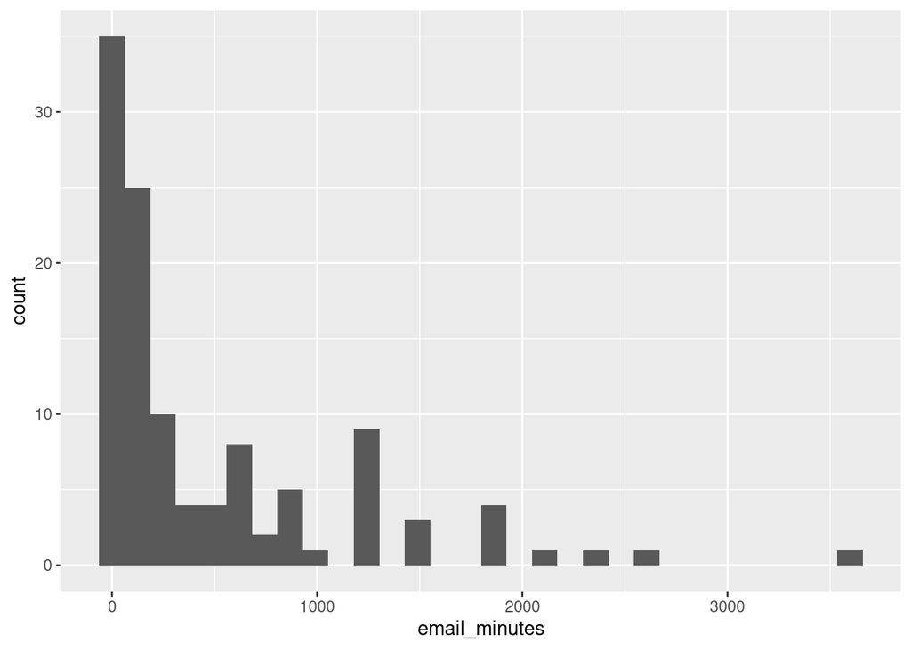

```r
ggplot(data = gss_email,
       mapping = aes(x = email_minutes)) +
  geom_histogram()
```

Let’s calculate a 95% confidence interval for the **median** amount of time Americans spend on email weekly. Remember to remove `eval = FALSE` when you are done coding.

```r
boot_dist <- numeric(1000)

for(i in 1:1000){

  set.seed(i)
  indices <- sample(1:nrow(gss_email), replace = TRUE)

  boot_median <- gss_email %>%
    slice(indices) %>%
    summarize(boot_median = median(email_minutes)) %>%
    pull()

  boot_dist[i] <- boot_median
}

boot_dist
boot_median
```

[output not shown]

```r
quantile(boot_dist, 0.025)
```

[output not shown]

```r
quantile(boot_dist, 0.975)
```

[output not shown]

Provide a careful interpretation of your interval in the context of the problem.